# dl_08 — UNet / UNet3+ Feature Map Visualization

## 8. Input reference

Before looking inside the model, here's the context: the model's inputs and the *answer key*. The interactive map below lets you flip through every input layer — the NAIP true-color imagery (what a person would see), each individual predictor band, and the ground-truth label map (MOD_CLASS) a human annotator assigned. Keep these in mind — every feature map further down is the model working its way from those inputs toward that label map.

### 8b. Interactive Leaflet map (folium)

Every input layer rendered as a georeferenced overlay on an **Esri satellite** basemap. This is a real web map — pan, zoom (scroll), and read coordinates just like in a GIS:

- The **radio control (top-right)** flips through layers one at a time: the **NAIP RGB (leaf-on)** and **Leaf-off RGB** true-color composites, the **MOD_CLASS label** (class colors, legend bottom-left), and each individual predictor band.
- **"None (basemap only)"** switches every overlay off so you can compare a band against the real ground in the satellite image.
- The **red outline** marks the patch footprint (256 m × 256 m) — zoom out and you can see exactly where in New York this patch sits.
- A **scale bar** (bottom-left) and the **cursor's lat/lon** (bottom-right) help relate what you see to ground distances and locations.

Continuous bands get a percentile (2–98%) contrast stretch; nodata/unlabeled pixels are transparent. **Geomorph_local** is the exception — it's *categorical* (ten landform types, not a measured quantity), so it's drawn with the standard geomorphon colors and its own legend pops up (bottom-right) while that layer is selected. Geomorphons describe local terrain shape from the DEM; watch how the water-collecting landforms — **valleys, hollows, footslopes, pits, flats** — trace the drainage network where wetlands tend to form.

Overlays are embedded in the notebook (work offline); only the basemap tiles need internet.

```
Built Leaflet map with 20 layers (+ 'None' toggle): ['NAIP RGB (leaf-on)', 'Leaf-off RGB', 'MOD_CLASS (label)', 'DEM', 'slope_local', 'Geomorph_local', 'flowacc', 'twi', 'CHM', 'r', 'g', 'b', 'nir', 'r_lo', 'g_lo', 'b_lo', 'nir_lo', 'pct_below_1m', 'pct_1m_to_5m', 'pct_above_5m']
```

Make this Notebook Trusted to load map: File -> Trust Notebook

[interactive chart not shown]

## 9. Encoder feature maps (top-variance channels)

The encoder as it *zooms out*. The top row (`enc0`, full resolution) responds to low-level cues — edges, texture, color/brightness contrast that still look a lot like the inputs. Each row down is half the size and a step more abstract, trading spatial detail for "meaning." Rows go fine → coarse. (We show the few most active channels at each level; there are dozens to hundreds in total.)

*Tip:* flip the map above to **NAIP RGB** and compare — in `enc0`/`enc1` you can usually recognize what a channel locked onto (a stream channel, a field edge, canopy texture). By `enc3` that's much harder; the maps are responding to broader patterns, not objects.

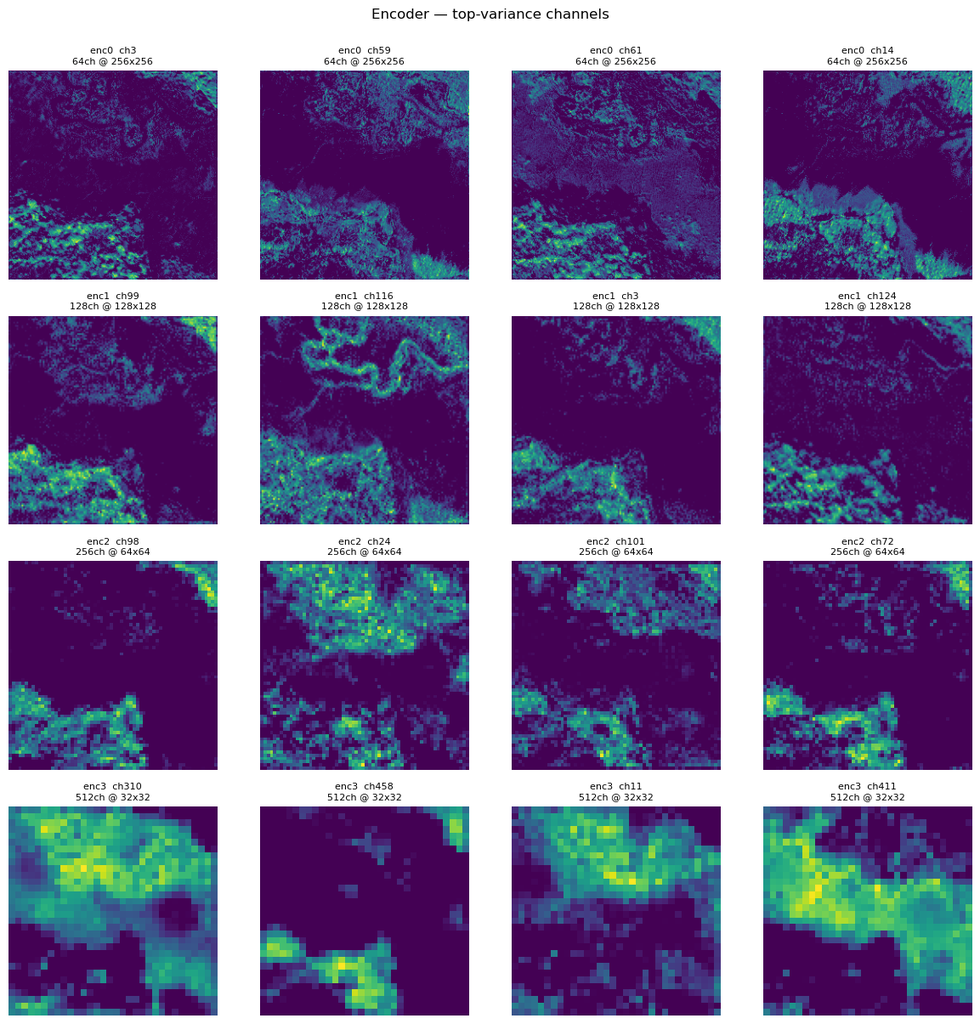

## 10. Bottleneck — BOTH views

The deepest, most compressed stage — the model's most abstract "summary" of the patch. It's small and blurry *by design*: at this point the network captures roughly *what is here* rather than *exactly where*. At depth 4 each bottleneck pixel summarizes a **16 m × 16 m** area of ground — enough to say "wet meadow around here," but not where its edge runs; re-drawing those edges is the decoder's job. Because this is the widest level (the most channels), we show it two ways: the **top-variance channels** and the **mean of all channels**, side by side.

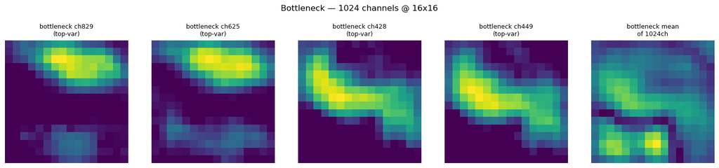

## 11. Decoder feature maps (top-variance channels)

The decoder *zooming back in*. Each stage merges the abstract bottleneck summary with the matching fine detail from the encoder (the "skip connections"), progressively sharpening edges and re-localizing the wetland boundaries. Rows go coarse → fine; `dec0` is the full-resolution node that feeds the final output head.

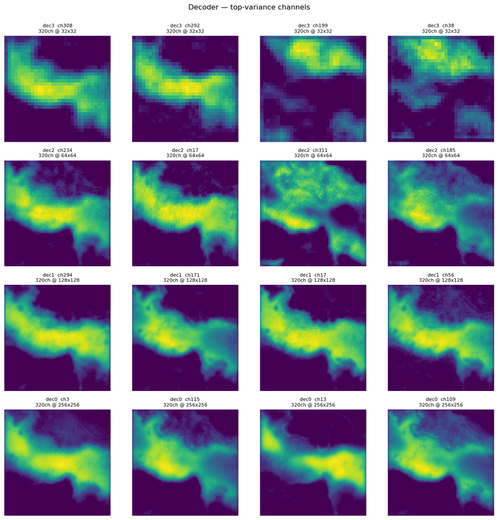

## 12. Whole-network mean-activation overview

One mean-activation image per stage, in order: encoder → bottleneck → decoder. This is the "signal flow" at a glance — watch the resolution shrink through the encoder, bottom out at the bottleneck, then grow back through the decoder, getting reorganized around the wetland features along the way.

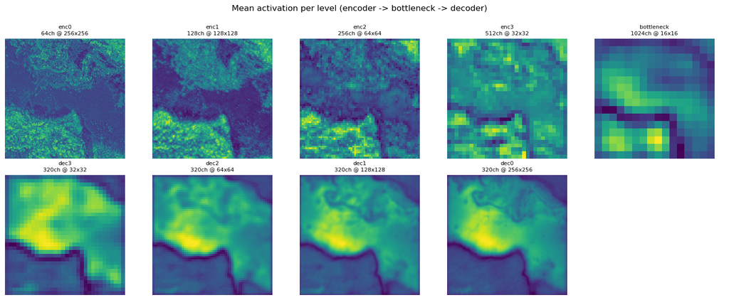

## 13. Logits → predicted classes

The payoff. The output head turns the final decoder feature map into a raw score (a **logit**) for each class at each pixel. **Softmax** converts those scores into probabilities that sum to 1, and **argmax** picks the highest-probability class as the prediction. Shown here: a probability heatmap per class, the predicted class map, and the ground truth for comparison.

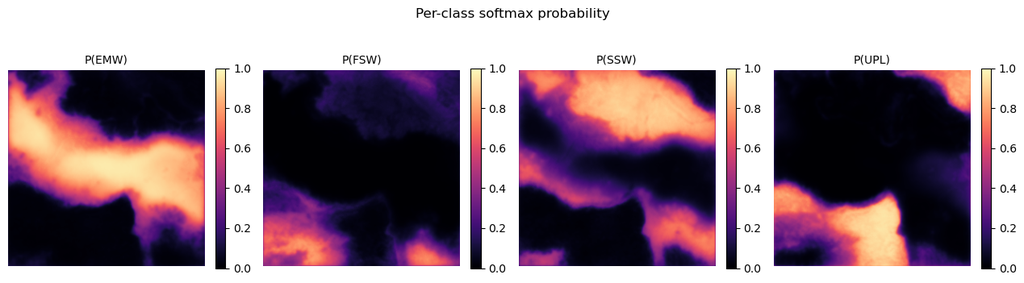

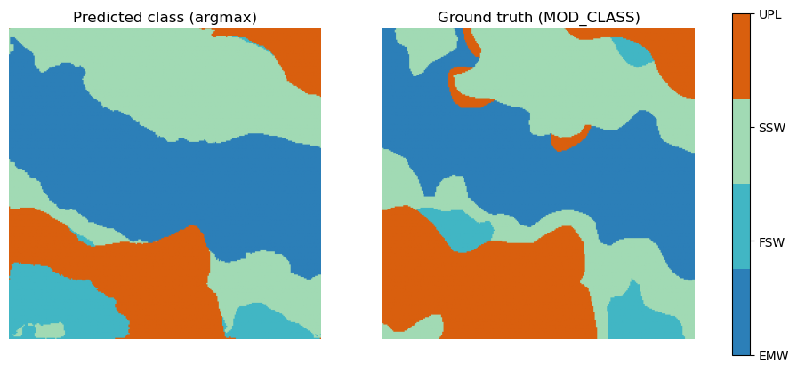

## 14. Deep-supervision side predictions (per-stage, coarse → fine)

**Deep supervision** means that during training the model wasn't graded only on its final full-resolution map — every decoder stage *and* the bottleneck got its own tiny prediction head and was graded on a "rough draft" of the wetland map at its own scale. That pressure pushes *every* level of the network to learn wetland-relevant features, not just the last one.

At inference those side heads are normally ignored (`eval` mode returns only the main, finest prediction), but they were saved with the model — so here we apply each one to the feature maps we captured in section 6 and watch the prediction sharpen from the blurry 16×16 bottleneck draft to the full-resolution final map. Top row = predicted class; bottom row = model confidence (the winning class's probability). The printout at the end quantifies how much each draft already agrees with the final answer.

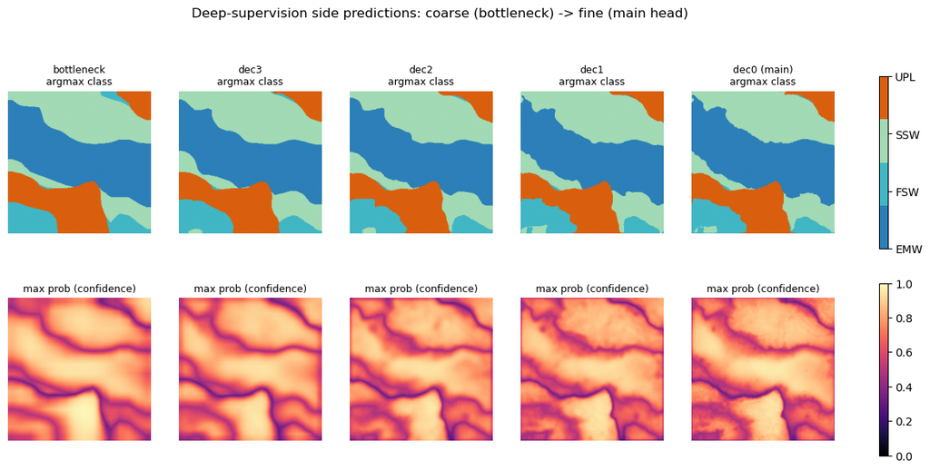

```
Per-stage agreement with the main head's prediction:
  bottleneck      93.4% of pixels match
  dec3            95.3% of pixels match
  dec2            96.2% of pixels match
  dec1            96.9% of pixels match
  dec0 (main)    100.0% of pixels match
```

## 15. Combined interactive map — predictions + inputs (folium)

The same Esri-satellite Leaflet map as section 8b, now with the **model's outputs** added — flip between *what the model saw* and *what it predicted*, all draped over real imagery. The layer control (top-right) now has **two independent radio groups**, so you can show one **model output** and one **input layer** at the same time — the output always draws on top (try *prediction confidence* over *NAIP RGB* to see what the model hesitates about):

- **+ Predicted class** (argmax) vs. **+ Ground truth** (MOD_CLASS) — flip back and forth to spot errors
- **+ Prediction confidence** (max probability) and a **+ P(class)** layer per class — where the model is sure vs. unsure
- all the NAIP / leaf-off composites and individual input bands from section 8b

Each group has a **"None"** option — pick None in both to see the bare satellite image. This is the one map to share if you want someone to explore the model interactively.

```
Built combined map: 7 model-output layers + 20 input layers, in two radio groups (each with its own 'None' option).
```

Make this Notebook Trusted to load map: File -> Trust Notebook

[interactive chart not shown]

## 16. Side-by-side error check — prediction vs. ground truth (synced maps)

Two maps locked together: **left = the model's prediction**, **right = the analyst's ground truth** (unlabeled pixels are transparent, letting the imagery show through). Pan or zoom either side and the other follows, so your eyes can stay on one spot while you compare. This is the fastest way to see *where* the model goes wrong — a marsh edge drawn too wide, an upland inclusion it missed. Same class colors as the legend (bottom-left).

Make this Notebook Trusted to load map: File -> Trust Notebook

[interactive chart not shown]

**To explore another patch or model:** change `CHECKPOINT_NAME` (Section 2) or `PATCH_NAME` (Section 5), then re-run from that cell down. `CHANNELS_PER_LEVEL`, `FEATURE_CMAP`, and `OVERLAY_OPACITY` (Section 3) control how the plots and the interactive maps (Sections 8b, 15, 16) are drawn.